# *Systematic Literature Review* (SLR)

Autora:* Mariane Nóbrega

Supervisão:* Israel José dos Santos Felipe

28 de abril de 2023

# 1 Introdução

Este documento pretende fornecer um panorama geral sobre a realização de uma revisão sistemática da literatura (*systematic literature review* – SLR) nas ciências sociais aplicadas, especificamente nas áreas de administração de empresas e ciências contábeis. Uma SLR deve gerar um *framework* na área de interesse, respondendo a uma ou mais questões de pesquisa e sendo replicável, por isso, normalmente, segue-se protocolos para sua execução.

O primeiro passo para iniciar uma SLR é pesquisar outras SLR já existentes sobre o tema. Isso vai servir para identificar a relevância da sua SLR e para indicar um caminho a ser seguido, o que estará na justificativa do seu trabalho. Você pode começar pelo próprio Google Acadêmico e depois pesquisar no Periódicos Capes.

O processo de seleção dos documentos científicos relevantes em uma SLR envolve gerenciar um conjunto de dados grande e, muitas vezes, não muito organizado. A cada vez que se amplia o escopo ou a estratégia de busca, pode-se gerar ainda mais resultados irrelevantes para o foco da sua SLR.

Assim, cada vez mais se intensifica o uso de técnicas de *machine learning* e *text mining* para automação do processo de revisões sistemáticas em diversas ferramentas propostas. Pode-se citar ferramentas aplicadas para área de ciências médicas, compatíveis apenas como as bases de dados dessa área (PUBMED, MEDLINE ou O´Mara-Eves dataset): RobotReviewer, LINGO3G, GATE, Abstrackr, Twister, SparkText e SwiftReview. Outras ferramentas incluem: libsvm (Library for Support Vector Machines), scikit-learn, Weka. Muitas dessas ferramentas utilizam técnicas como a tokenização de palavras e sentenças.

Nesse sentido, entende-se que há uma grande relevância na construção da estratégia de busca, que, quando é falha, gera resultados errados ou imprecisos. Para mitigar essas falhas é interessante elaborar corretamente a pergunta/questão de pesquisa, que, quando bem estruturada, refletirá em uma estratégia de busca adequada.

Várias estratégias são utilizadas para construção da questão de pesquisa, como as estratégias PICO, PICOC, PICo, 3WH, BeHEMoTh, CIMO, PEO, PEICO(S), PICOT, PICOTS, PICOTT, PVO, PICOD, SPICE, SPIDER, PCC, ECLIPSE e TQO. A grande maioria é voltada para a área da saúde, mas algumas podem ser adaptadas para outras áreas.

Um dos mais famosos é o modelo PICO, de Richardson, Wilson, Nishikawa e Hayward (1995), que considera:

- **P** - população, paciente/indivíduos ou problema abordado (*Population/Patient/Problem*);
- **I** - intervenção ou a exposição que será considerada (*Intervention*);
- **C** - comparação da intervenção ou da ação quando esta for necessária e relevante (*Comparison/Control*); Nem sempre esse item é contemplado; e
- **O** - desfechos ou resultados esperados de interesse (*Outcome*).

*Exemplo de construção:*

- *Questão de pesquisa*: Como as métricas mais utilizadas para sustentabilidade organizacional diferem das métricas de desempenho tradicionais?
- *Termos para PICO*: sustentabilidade (P), métricas para sustentabilidade (I), métricas tradicionais (C), desempenho organizacional (O);
- *Tradução para busca*: sustainability (P), metrics for sustainability (I), traditional metrics (C), organizational performance (O);
- *Combinações/strings de busca específicas*: ESG OR “environmental, social and governance” OR “corporate social responsibility” OR CSR (P); metrics OR score OR ranking OR indicators (I), “performance measures” (C), organizational AND (actuation OR action OR behavior OR conduct) (O);
- *Construção da estratégia de busca*: ((ESG OR “environmental, social and governance” OR “corporate social responsibility” OR CSR) AND (metrics OR score OR ranking OR indicators) AND “performance measures” AND organizational AND (actuation OR action OR behavior OR conduct));

Normalmente as variações do modelo PICO mantem esses tópicos principais e incluem alguns outros tópicos que podem ajudar a busca. Um exemplo interessante é a estratégia PICOC (*Population, Intervention, Comparison, Outcome, Context*), que inclui o contexto da pesquisa, como localização geográfica. A PICOC é a estratégia utilizada pela ferramenta Parsifal, software online para construção de SLRs.

Outra estratégia interessante é a PICOD ou PICOS, que considera o design (desenho) do estudo ou *study design* (desenho do estudo). Essa estratégia inclui a busca pelos instrumentos de coletas de dados ou métodos de pesquisa utilizados nos estudos, por exemplo regressão (regression) ou painel (panel data). Nesse caso, a experiência do pesquisador pode ser útil para restringir os métodos considerados mais adequados no tipo de estudo em questão.

Também é importante destacar que se trata de um processo de tentativa e erro até se encontrar a estratégia de busca mais adequada em cada base de dados. O uso de descritores, operadores booleanos (and, or, not e same) e caracteres coringas (como os truncadores *, ? ou $) podem ajudar, mas a transformação do objetivo/problema de pesquisa na estratégia de busca é mais conceitual. Novamente, a experiência de leitura do pesquisador o ajudará a selecionar o vocabulário controlado (as padronizações) específico da área em que pesquisa, para que se coloque descritores e sinônimos, além das possibilidades de plural/singular e grafias. Para o plural, é possível truncar o final de uma palavra, por exemplo, ao invés de utilizar “metric for sustainability OR metrics for sustainability” é possível utilizar apenas “metric$ for sustainability”. Pode-se utilizar uma interrogação (?) para substituir apenas um caractere, por exemplo ?SG para ESG (que também pode ser encontrado na sigla em português “ASG”), utilizar um asterisco (*) para substituir um ou mais caracteres, como responsib* para as variações de responsibility, e um cifrão ($) para substituir um ou nenhum caractere, como em metric$, que retornará singular (metric) ou plural (metrics).

Além disso, é necessário definir filtros para os critérios de inclusão/exclusão da busca estipulados pelo pesquisador, como recorte temporal, disponibilidade de acesso (ex.: texto completo disponível), área de publicação, autor(es) de referência, cobertura, idioma e número de páginas. Devem ser informados os motivos de inclusão/exclusão. Lembrando que, a depender das bases de dados escolhidas para as buscas, será necessário mesclar os resultados ao final para remover arquivos duplicados.

Além dessa construção da string de busca, cabe ao pesquisador escolher os tipos de documentos que serão considerados (cobertura). A comunidade acadêmica, de forma geral, opta por referências tradicionais, advindas de, normalmente, arquivos digitais de revistas científicas digitais (periódicos/journals), que passam por critérios de aceitação, como peer-review, blind- review ou escolha pelos editores ou conselho/comissão editorial, sendo consideradas white papers.

Todavia, referências não convencionais, como open-archives (e-prints), pre-prints e open-access, têm sido consideradas importantes em casos de temas incipientes ou com poucos estudos disponíveis. Trata-se da chamada grey literature, que envolve, ainda, proceedings de eventos científicos/acadêmicos (normalmente anais de congressos/conferências), livros/livros indexados, teses e dissertações (há bancos de teses e dissertações disponíveis por várias instituições de ensino) e documentos variados. Assim, é possível que várias formas de difusão do conhecimento científico sejam utilizadas como fontes de informação. A grey literature normalmente não está publicada em canais convencionais de transmissão científica e sua qualidade mínima não foi garantida por pareceristas.

Os repositórios do tipo open access (repositórios de Arquivos de Acesso Livre, como repositórios institucionais) podem incluir documentos com probabilidade de se transformar em white papers (assim como os opens archives), ampliando a possibilidade de se publicar pesquisas em desenvolvimento e abertos a sugestões de melhorias e críticas. Assim, trabalhos em andamento em forma de pre-prints são publicados em open-archives para passar pelo crivo da comunidade científica. Os open archives são disponibilizados em repositórios como o Portal de Periódicos da Capes, porém são vinculados a instituições, como cursos de pós-graduação de universidades. É o caso dos working papers da Faculdade de Economia, Administração, Contabilidade e Atuária (FEA-USP).

Porém, é importante destacar que, sobretudo na área de ciências sociais aplicadas, se espera que essa “transformação” ocorra em um intervalo de tempo menor do que em outras áreas (como na área das ciências médicas). Entende-se que a publicação em revistas científicas pode requerer um tempo considerável, podendo chegar até a um ano (revistas que demoram mais que isso normalmente são de baixa qualidade). Nesse sentido, deve-se prestar atenção à versões eletrônica, pois um documento científico qualquer que passe mais de cinco anos sem ser publicado em periódicos têm sua probabilidade de publicação reduzida, e, portanto, seu uso deve ser repensado.

Além disso, existem pontuações de open access, gerando duas formas principais: o gold open access (gold OA), cujos periódicos normalmente estão disponíveis no Diretório de Jornais de Acesso Aberto (Directory of Open Access Journals - DOAJ), e o green open acess (green OA ou self-archiving/autoarquivamento), cuja versão do manuscrito fica totalmente acessível em um repositório. Um gold OA tem sua versão final acessível permanentemente sem restrições após a publicação e os direitos autorais pertencem aos autores (os autores devem ser citados em caso de utilização do trabalho por outras pessoas). Já no caso dos green OA, a versão depositada em um repositório depende do financiador, pois os direitos autorais são da editora do periódico, havendo restrições para utilização do trabalho por outros pesquisadores, a depender das políticas de self-archiving.

Outro ponto importante a se destacar sobre uma SLR é a recomendação de que ela seja realizada por mais de uma pessoa, de preferência uma equipe. Muitas vezes isso é difícil, mas é interessante se tentar fazer com pelo menos duas pessoas, para melhorar a credibilidade dos resultados.

De forma geral, percebe-se que o processo de SLR inclui o planejamento, o desenvolvimento e os resultados. O planejamento envolve:

- uma pesquisa exploratória para avaliar a necessidade da SLR (se já existem SLRs sobre o tema e qual a justificativa para uma nova);
- a escolha de um protocolo (como um PRISMA ou outro específico da área), com o intuito de reduzir a possibilidade de vieses;
- a definição de pelo menos uma questão de pesquisa e do objetivo e escolha dos seus termos/descritores;
- a escolha da estratégia de busca com base em um modelo, como o PICO, o PICOC ou o PICOD;
  - a definição de possibilidades de sinônimos ou variações para esses termos (dentro do vocabulário padrão ou predominante na área de interesse);
  - a escolha dos repositórios ou bases de dados a serem utilizadas, como WoS e Scopus;
  - a construção da string de busca com auxílio de operadores booleanos e caracteres curinga;
  - a escolha dos critérios de seleção/inclusão e dos critérios de exclusão;
  - testes nas bases de dados para a escolha da string mais adequada. É importante dizer que normalmente há várias mudanças no argumento original de busca, inclusive podendo haver mudanças de base para base.
- a escolha dos critérios de qualidade a serem considerados, por exemplo, relacionados ao que se espera encontrar nos objetivos, metodologia ou resultados dos trabalhos analisados (Ex.: A questão de pesquisa foi respondida?). Inclusive é interessante estipular uma “classificação” para os estudos (por exemplo, uma nota de 0 a 5, a depender dos critérios estipulados).

A partir desse planejamento, o desenvolvimento propriamente dito da SLR envolve seguir as etapas definidas pelo protocolo escolhido, extrair os arquivos ou os metadados dos documentos retornados em cada base de dados e selecionar os estudos que farão parte da SLR. O pesquisador pode extrair os arquivos completos em .pdf ou apenas seus metadados, no formato BibTeX.

O processo de seleção pode iniciar com a leitura (screening) dos títulos, resumos e palavras-chave, que possivelmente acarretará a exclusão de alguns trabalhos. Em seguida, pode-se optar por ler a introdução e a conclusão e, por fim, o texto inteiro, sempre registrando todos os trabalhos que foram incluídos ou excluídos (conforme os critérios de qualidade estabelecidos), de preferência em um documento, como o PRISMA Flow Diagram. Ao final é importante analisar se os estudos remanescentes têm as informações necessárias para responder à questão de pesquisa. Por isso, muitas vezes é interessante que o estudo não seja feito por apenas um pesquisador, pois a avaliação dos estudos selecionados, a imparcialidade e a objetividade são de suma importância. Além disso, a revisão dos estudos selecionados deve garantir que trabalhos relevantes não tenham sido excluídos do pool. Nesta etapa, podem ser utilizados formulários de extração de dados, detalhando informações necessárias para responder à questão de pesquisa.

Por fim, os resultados devem ser relatados a partir de um artigo científico ou mesmo como parte de uma dissertação ou tese. Podem ser utilizados métodos estatísticos, tabelas, gráficos, figuras, etc. Nesta etapa também podem ser utilizados alguns softwares, como, por exemplo, gerenciadores de referências, como Mendeley, Zotero, EndNote ou JabRef, que também ajudam no gerenciamento dos metadados dos documentos e na checagem final das referências.

# 2 Escolhendo um protocolo

O ideal é que se escolha um protocolo ou *checklist* para seguir em uma SLR. Eles servem para orientar o passo a passo e para reduzir os riscos de viés. Um dos mais conhecidos é o da Prisma *statements* (*Preferred Reporting Items for Systematic Reviews and Meta-Analysis*), através do seu *flow diagram* e do seu *checklist*, que mostra o que cada parte da SLR deve ter, desde o título até as conclusões. Além dele, na área de gestão, há o *checklist* de Williams Jr. et al. (2021), que fornece etapas detalhadas para conduzir a revisão em gestão.

# 3 *Checklist* PRISMA 2020

O checklist PRISMA inclui 27 itens para orientar o relato de revisões sistemáticas. No artigo de Page et al. (2021) os autores explicam por que o relatório de cada item é recomendado, apresentam pontos que detalham as recomendações de relatórios e apresentam exemplos de revisões publicadas. Como a maior parte dos exemplos se refere à área da saúde, recomenda-se que, para mais detalhes, leia-se diretamente o artigo.

## 3.1 Título

> Identifique o relatório como uma revisão sistemática.  
> Exemplo: Avaliação de eficiência para fundos de pensão: reflexões de uma revisão sistemática da literatura

## 3.2 Resumo e Palavras-chave

### 3.2.1 Resumo

1. Identifique o relatório como uma revisão sistemática
2. Forneça uma declaração explícita do(s) objetivo(s) principal(ais) ou questão(ões) abordada(s) pela revisão
3. Especifique os critérios de inclusão e exclusão para a revisão
4. Especifique as fontes de informação (como bancos de dados, registros) usadas para identificar os estudos e a data em que cada um foi pesquisado pela última vez
5. Especifique os métodos usados para avaliar o risco de viés nos estudos incluídos - prisma
6. Especificar os métodos usados para apresentar e sintetizar resultados
7. Forneça o número total de estudos e participantes incluídos e resuma as características relevantes dos estudos
8. Apresentar resultados para os desfechos principais, preferencialmente indicando o número de estudos incluídos e participantes para cada um. Se a meta-análise foi realizada, relate a estimativa resumida e o intervalo de confiança/credível. Ao comparar grupos, indique a direção do efeito (ou seja, qual grupo é favorecido)
9. Forneça um breve resumo das limitações das evidências incluídas na revisão (como risco de viés, inconsistência e imprecisão do estudo)
10. Forneça uma interpretação geral dos resultados e implicações importantes
11. Especifique a principal fonte de financiamento para a revisão
12. Forneça o nome do registro e o número do registro

### 3.2.2 Palavras-chave

Escolhas palavras que identifique a população, intervenções e resultados.

## 3.3 Introdução

### 3.3.1 Justificativa

> Descreva a justificativa para a revisão no contexto do conhecimento existente.
- Descrever o estado atual do conhecimento na área;
- Se já estiverem disponíveis revisões abordando a mesma questão, explicar porque a nova revisão foi feita.
  - Por exemplo:
    - Revisões anteriores estão desatualizadas ou têm resultados discordantes;
    - Novos métodos de revisão estão disponíveis para abordar a questão da revisão;
    - Os pareceres existentes são falhos metodologicamente; ou
    - Uma revisão atual foi encomendada.

## 3.4 Métodos

### 3.4.1 Critério de elegibilidade

> Especifique os critérios de inclusão e exclusão para a revisão e como os estudos foram agrupados para as sínteses.

### 3.4.2 Fontes de informação

> Especifique todos os bases de dados, registros, sites, organizações, listas de referência e outras fontes pesquisadas ou consultadas para identificar estudos.
- Especifique a data em que cada fonte foi pesquisada ou consultada pela última vez.
- Se bases de dados bibliográficas foram pesquisadas, especifique para cada base de dados seu nome (como *Web of Science® - WoS* e *Scopus*), a interface ou plataforma por meio da qual o base de dados foi pesquisado (como Periódicos Capes e EBSCOhost) e os dados de cobertura (onde essas informações são fornecidas).
- Se registros de estudos (como a Plataforma Brasil), bancos de dados regulatórios e outros repositórios online (como spell, SciELO, Science Direct, etc.) foram pesquisados, especifique o nome de cada fonte e quaisquer restrições de dados aplicadas.
- Se sites, mecanismos de pesquisa ou outras fontes on-line foram navegados ou pesquisados, especifique o nome e o URL (*uniform resource locator*) de cada fonte.
- Se revistas ou anais de congressos foram consultados, especifique os nomes de cada fonte, as datas abrangidas e como foram pesquisadas.

### 3.4.3 Estratégia de pesquisa

> Apresentar as estratégias de busca **completas** para todos os bancos de dados, registros e sites, incluindo quaisquer filtros e limites usados (como data ou idioma) e justifique-os vinculando-os aos critérios de elegibilidade da revisão.
- Se abordagens publicadas, como filtros de pesquisa projetados para recuperar tipos específicos de registros (por exemplo, filtro para Categoria “Business Finance”) ou estratégias de pesquisa de outras revisões sistemáticas, foram usadas, cite-as. Se as abordagens publicadas foram adaptadas, por exemplo, se os filtros de pesquisa existentes foram alterados, observe as alterações feitas.
- Se a estratégia de busca foi revisada por pares, relate o processo de revisão por pares usado e especifique qualquer ferramenta usada, como o *Peer Review of Electronic Search Strategies* (PRESS) checklist.
- Se a estrutura da estratégia de busca adotada não foi baseada em uma abordagem estilo PICO, descreva a estrutura conceitual final e quaisquer explorações que foram realizadas para alcançá-la.

> Observação: As strings de pesquisa e suas combinações normalmente são definidas por um processo de tentativa e erro, porém é possível utilizar (de forma auxiliar) o *JournalFinder* da Elsevier para localização dos termos mais comuns sobre o tema.

## 3.5 Processo de seleção

> Especifique os métodos usados para decidir se um estudo atendeu aos critérios de inclusão da revisão, incluindo quantos revisores examinaram cada registro e cada relatório recuperado, se trabalharam de forma independente e, se aplicável, detalhes das ferramentas de automação usadas no processo.

**Elementos essenciais para revisões sistemáticas independentemente dos processos de seleção utilizados**

- Relate quantos revisores examinaram cada registro (título/resumo) e cada relatório recuperado, se vários revisores trabalharam de forma independente (ou seja, desconheciam as decisões uns dos outros) em cada estágio de triagem ou não (por exemplo, registros triados por um revisor e exclusões verificadas por outro) e quaisquer processos usados para resolver divergências entre os rastreadores (por exemplo, encaminhamento a um terceiro revisor ou por consenso).
- Relatar quaisquer processos usados para obter ou confirmar informações relevantes dos pesquisadores do estudo.
- Se os resumos ou artigos precisarem de tradução para outro idioma para determinar sua elegibilidade, relate como eles foram traduzidos (por exemplo, perguntando a um falante nativo ou usando programas de software).

**Veja Page et al. (2021) para verificar os elementos essenciais para revisões sistemáticas utilizando ferramentas de automação no processo de seleção ou usando *crowdsourcing* ou avaliações anteriores “conhecidas” no processo de seleção**

> Page et al. (2021) comentam as vantagens e desvantagens de cada uma das várias abordagens para a seleção de estudos existentes.

## 3.6 Processo de coleta de dados

> Especifique os métodos usados para coletar dados de relatórios, incluindo quantos revisores coletaram dados de cada relatório, se eles trabalharam de forma independente, quaisquer processos para obter ou confirmar dados de investigadores de estudo e, se aplicável, detalhes de ferramentas de automação usadas no processo.

## 3.7 Itens de dados

> Liste e defina todos os resultados para os quais os dados foram solicitados. Especifique se todos os resultados compatíveis com cada domínio de resultado em cada estudo foram buscados (por exemplo, para todas as medidas, pontos de tempo, análises) e, se não, os métodos usados para decidir quais resultados coletar

> Liste e defina todas as outras variáveis para as quais os dados foram solicitados (como características dos participantes e da intervenção, fontes de financiamento). Descreva quaisquer suposições feitas sobre qualquer informação ausente ou pouco clara.

*Exemplo*

> “Coletamos dados sobre:  
> o relatório: autor, ano e fonte de publicação;  
> o estudo: características da amostra, demografia social e definição e critérios usados; os participantes: características específicas (variáveis analisadas);  
> o desenho e as características da pesquisa: mecanismo de amostragem, métodos de análise; a intervenção: tipo, duração, quantidade, tempo e modo de distribuição.”

## 3.8 Estudo de avaliação de risco de viés

> Especifique os métodos usados para avaliar o risco de viés nos estudos incluídos, incluindo detalhes da(s) ferramenta(s) usada(s), quantos revisores avaliaram cada estudo e se eles trabalharam de forma independente e, se aplicável, detalhes das ferramentas de automação usadas em o processo.

## 3.9 Medidas de efeito

> Especifique para cada resultado a(s) medida(s) de efeito (como taxa de risco, diferença média) usada na síntese ou apresentação dos resultados

## 3.10 Métodos de síntese

> Descrever os processos usados para decidir quais estudos eram elegíveis para cada síntese (como tabular as características da intervenção do estudo e comparar com os grupos planejados para cada síntese (item “Critério de elegibilidade”))

> Descrever quaisquer métodos necessários para preparar os dados para apresentação ou síntese, como tratamento de estatísticas resumidas ausentes ou conversões de dados

> Descrever quaisquer métodos usados para tabular ou exibir visualmente (gráficos) os resultados de estudos e sínteses individuais

> Descreva quaisquer métodos usados para sintetizar os resultados e justifique a(s) escolha(s). Se uma meta-análise foi realizada, descreva o(s) modelo(s), método(s) para identificar a presença e a extensão da heterogeneidade estatística e o(s) pacote(s) de software usado(s). [^1]

> Descrever quaisquer métodos usados para explorar possíveis causas de heterogeneidade entre os resultados do estudo (como análise de subgrupo, meta-regressão). [^2]

> Descrever quaisquer análises de sensibilidade realizadas para avaliar a robustez dos resultados sintetizados.[^3]

## 3.11 Avaliação de viés de relatório

> Descrever quaisquer métodos (revisores, processos ou ferramentas de automação) usados para avaliar o risco de viés devido a resultados ausentes em uma síntese (decorrente de vieses de relatórios)

## 3.12 Avaliação de certeza

> Descrever quaisquer métodos (ferramenta ou sistema - e versão) usados para avaliar a certeza (ou confiança) no conjunto de evidências de um resultado
- Descrever as regras de decisão usadas para chegar a um julgamento geral do nível de certeza (como alto, moderado, baixo, muito baixo), juntamente com a interpretação pretendida (ou definição) de cada nível de certeza.
- Se foram feitas quaisquer adaptações a uma ferramenta ou sistema existente para avaliar a certeza, especifique as adaptações com detalhes suficientes para que a abordagem seja replicável.

## 3.13 Seleção de estudo

> Descreva os resultados do processo de busca e seleção, desde o número de registros identificados na busca até o número de estudos incluídos na revisão, de preferência usando um diagrama de fluxo, como PRISMA.
- Relate, preferencialmente usando um diagrama de fluxo, o número de: registros identificados; registros excluídos antes da triagem (por exemplo, porque eram duplicados ou considerados inelegíveis por classificadores de máquinas); registros rastreados; registros excluídos após triagem de títulos ou títulos e resumos; relatórios recuperados para avaliação detalhada; relatórios potencialmente elegíveis que não eram recuperáveis; relatórios recuperados que não atenderam aos critérios de inclusão e os principais motivos de exclusão (como desenho de estudo inelegível, população inelegível); e o número de estudos e relatórios incluídos na revisão. Se aplicável, os autores também devem relatar o número de estudos em andamento e relatórios associados identificados.
- Se a revisão for uma atualização de uma revisão anterior, relate os resultados do processo de busca e seleção para a revisão atual e especifique o número de estudos incluídos na revisão anterior. Uma Box adicional pode ser adicionada ao fluxograma indicando o número de estudos incluídos na revisão anterior.
- Se aplicável, indique no diagrama de fluxo do PRISMA quantos registros foram excluídos por um humano e quantos por ferramentas de automação.
- Considere, se possível, relatar o número de registros identificados em cada banco de dados ou registro pesquisado (em vez do número total em todos os bancos de dados/registros).
- Se ferramentas de automação foram usadas, indique quantos registros foram excluídos por uma pessoa e quantos foram excluídos por ferramentas de automação.

*Diagrama de fluxo PRISMA 2020 para novas revisões sistemáticas que incluíram pesquisas de bancos de dados e registros apenas:*

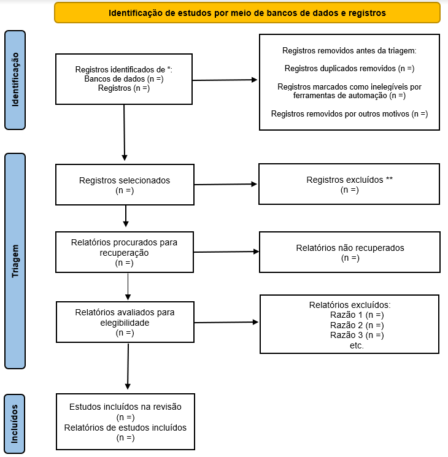

Fonte: [PRISMA Flow Diagram.](http://prisma-statement.org/prismastatement/flowdiagram.aspx)

> Cite estudos que possam parecer atender aos critérios de inclusão, mas que foram excluídos, e explique por que foram excluídos.

## 3.14 Características do estudo

> Cite cada estudo incluído e apresente as principais características de cada estudo em uma tabela ou figura (considerando um formato que facilite a comparação das características entre os estudos).

## 3.15 Risco de viés nos estudos

> Apresentar avaliações de risco de viés para cada estudo incluído
- Apresentar tabelas ou figuras indicando para cada estudo o risco de viés em cada domínio/componente/item avaliado e o risco geral de viés no nível do estudo.
- Apresentar justificativa para cada risco de viés – por exemplo, na forma de citações relevantes dos estudos incluídos.

## 3.16 Resultados de estudos individuais

> Para todos os resultados, apresentar para cada estudo: (a) estatísticas resumidas para cada grupo (quando apropriado) e (b) uma estimativa de efeito e sua precisão (como intervalo de confiança/crível), de preferência usando tabelas ou gráficos estruturados

## 3.17 Resultados das sínteses

> Para cada síntese, resuma brevemente as características e o risco de viés entre os estudos contribuintes

> Apresentar resultados de todas as sínteses estatísticas realizadas. Se a meta-análise foi realizada, apresente para cada uma a estimativa resumida e sua precisão (como intervalo de confiança/crível) e medidas de heterogeneidade estatística. Se comparar grupos, descreva a direção do efeito

> Apresentar resultados de todas as investigações de possíveis causas de heterogeneidade entre os resultados do estudo

> Apresentar resultados de todas as análises de sensibilidade realizadas para avaliar a robustez do sintetizado resultados

## 3.18 Risco de reportar vieses nas sínteses

> Apresentar avaliações de risco de viés devido a resultados ausentes (decorrentes de vieses de relatórios) para cada síntese avaliada

## 3.19 Certeza de evidência

> Apresentar avaliações de certeza (ou confiança) no corpo de evidências para cada resultado avaliado

## 3.20 Discussão

- Forneça uma interpretação geral dos resultados no contexto de outras evidências
- Discuta quaisquer limitações das evidências incluídas na revisão
- Discuta quaisquer limitações dos processos de revisão usados
- Discuta as implicações dos resultados para a prática, política e pesquisas futuras

## 3.21 Registro e protocolo

- Forneça informações de registro para a revisão, incluindo nome e número de registro, ou declare que a revisão não foi registrada.
- Indique onde o protocolo de revisão pode ser acessado ou declare que um protocolo não foi preparado
- Descrever e explicar quaisquer alterações nas informações fornecidas no registro ou no protocolo

## 3.22 Apoio

> Descrever as fontes de apoio financeiro ou não financeiro para a revisão e o papel dos financiadores ou patrocinadores na revisão

## 3.23 Interesses conflitantes

> Declarar quaisquer interesses conflitantes dos autores da revisão

## 3.24 Disponibilidade de dados, código e outros materiais

> Relate quais dos seguintes itens estão disponíveis ao público e onde podem ser encontrados: modelos de formulários de coleta de dados; dados extraídos dos estudos incluídos; dados usados para todas as análises; código analítico; quaisquer outros materiais usados na revisão

# 4 *Checklist* de Williams Jr. et al. (2021)

Williams Jr. et al. (2021) discutem como as revisões sistemáticas da literatura podem aprimorar a pesquisa em administração e abordam as deficiências atuais da pesquisa em administração. Assim, os autores apresentam uma diretriz de execução de revisão de literatura sistemática detalhada, descrevendo as etapas de revisão de literatura sistemática e fornecendo as chaves para uma implementação eficaz na área de gestão. Os autores destacam, ainda, que nem todos os itens citados serão relevantes para todas as revisões sistemáticas.

## 4.1 Etapa 1 - Planejando a Revisão: Seu Protocolo

*Planejamento inicial*

**A. Identificando o Foco Amplo da Revisão Sistemática**

- Determine o foco geral para a revisão sistemática.
- Realizar pesquisas em bancos de dados para determinar se a revisão sistemática foi realizada anteriormente.
- Se uma revisão sistemática anterior tiver sido realizada, determine se uma revisão adicional serviria a um propósito, modificaria ou restringiria o foco ou abandonaria a revisão. Identifique os benefícios de conduzir uma revisão sistemática para abordar a questão geral.

**B. Montagem da equipe de pesquisa de revisão sistemática (*systematic research review team* - SRRT)**

- Com base na área de foco geral identificada na Etapa 1A, identifique os tipos de especialização, interesse e comprometimento de tempo necessários para os possíveis membros da equipe de pesquisa.
- Recrute potenciais membros da equipe de pesquisa.
- Forneça aos membros da equipe informações básicas sobre uma revisão sistemática, compartilhando os principais artigos sobre o processo antes de sua primeira reunião do SRRT.
- Na reunião inicial da SRRT, identifique um membro da equipe para atuar como coordenador principal da revisão.
- Estabeleça as normas do grupo SRRT para comunicação, progresso do trabalho e objetivos gerais da revisão.

**C. Identificando o foco demarcado da revisão (pela SRRT)**

- Indique claramente a(s) questão(ões) de pesquisa a ser(em) respondida(s) pela revisão.
- Revisite a questão de saber se uma revisão sistemática é um método apropriado para responder à(s) questão(ões) de pesquisa declarada(s).

*Estabelecendo protocolo de revisão*

**D. Estabelecimento de critérios para inclusão no pool para responder à(s) pergunta(s) de pesquisa declarada(s)**

- Para responder à(s) questão(ões) de pesquisa, determine os critérios que a literatura precisa satisfazer para ser incluída no pool inicial.
- Procure orientação de especialistas ou de um grupo consultivo sobre se os critérios produzirão literatura para responder à(s) questão(ões) da pesquisa.
- Revise cuidadosamente o texto dos critérios para garantir que todos os membros da SRRT entendam os critérios.
- Teste (ou piloto) a aplicação dos critérios por todos os membros da equipe, revisando a mesma amostra de artigos para determinar se os critérios são adequados para incluir ou excluir artigos. Modifique os critérios com base no feedback.

**E. Estabelecendo literatura para incluir na pesquisa**

- Determine e registre quais tipos de literatura incluir no estudo e por quê (revisado por pares? Não publicado? Relatórios do governo? Somente empírico? Dissertações? etc.).
- Determine e registre quais bancos de dados ou fontes de literatura serão usados e justifique por quê.
- Determine e registre os limites da pesquisa (data, relevância para os critérios, tipos ou qualidade dos periódicos, etc.) e justifique o motivo.
- Determine e registre o motivo pelo qual certa literatura foi excluída e justifique o motivo.
- Determine e registre quais disciplinas serão pesquisadas e por quê outras serão excluídas.

**F. Estabelecendo a mecânica da pesquisa (termos de pesquisa)**

- Defina os termos de pesquisa que serão usados para identificar literatura potencial com base nas Etapas 1D e 1E.
- Identifique quem conduzirá a pesquisa e por que essa pessoa ou pessoas foram selecionadas.
- Especifique as áreas do artigo que serão pesquisadas (resumo, título, palavras-chave, etc.) e documente por quê essas áreas foram pesquisadas e outras áreas excluídas.
- Defina o processo para determinar se um artigo retornado pela pesquisa é considerado relevante para inclusão no pool de revisão pela SRRT.
- Determine como a(s) pessoa(s) que conduz(em) a pesquisa decide(m) incluir ou não a literatura no pool inicial.

**G. Garantia de transparência e capacidade de replicação**

- Estabeleça um processo para registrar as decisões e o processo de inclusão ou exclusão de artigos que esteja disponível para todos os membros da Equipe de Pesquisa de Revisão Sistemática (SRRT).
- Estabeleça normas na SRRT para garantir que todas as etapas, decisões e perguntas sejam capturadas para permitir a transparência.
- Estabeleça normas na SRRT para garantir que todas as mecânicas da pesquisa possam ser replicadas por outras pessoas e retorne resultados da literatura semelhantes.

**H. Estabelecendo procedimentos para limitar ou remover viés**

- Identifique as etapas a serem tomadas pela SRRT para limitar ou remover vieses durante o processo de pesquisa.
- Estratégia opcional: Mais de uma pessoa realiza uma pesquisa no mesmo banco de dados e diferentes resultados são conciliados.
- Estratégia opcional: incluir literatura cinzenta[^4] ou material não publicado para limitar o viés de publicação.
- Explique as razões para usar ou não literatura cinzenta e material não publicado.
- Se estiver usando literatura cinzenta ou material não publicado, estabeleça um processo claro para solicitar, obter e selecionar a literatura.

**I. Estabelecendo procedimentos para avaliar a qualidade da literatura**

- Estabeleça um processo ou critério para determinar o nível de qualidade da literatura incluída na revisão.
- Registre as razões para usar este processo ou critérios para determinar este nível de qualidade e excluir a literatura que não possui este nível de qualidade.
- Se estiver usando principalmente literatura quantitativa/empírica, determine a amostra e os métodos apropriados para inclusão.
- Se estiver usando principalmente literatura qualitativa, determine os parâmetros conceituais apropriados para inclusão (por exemplo, com base em pesquisa ou teoria anterior, ou meramente anedótico, etc.).

## 4.2 Etapa 2 - Identificando o Universo de Estudos Potencialmente Relevantes

**A. Estabelecendo as funções e responsabilidades dos membros da SRRT**

- Designe membro(s) da equipe para conduzir uma pesquisa nos bancos de dados identificados para determinar qual literatura incluir no pool inicial para consideração de inclusão de revisão.
- Designe membros da equipe para criar um conjunto de artigos em potencial para revisão usando os critérios de pesquisa e relevância estabelecidos na Etapa 1.
- Designe um membro da equipe ou aluno de pós-graduação para obter artigos com texto completo digital no pool inicial e carregar artigos no repositório on-line compartilhado.

**B. Garantia de transparência e capacidade de replicação**

- Siga o processo estabelecido para registrar notas durante a implementação dos critérios de pesquisa para transparência e para garantir a capacidade de replicar o processo de pesquisa.
- Registre informações básicas dos resultados da pesquisa, quantos artigos de cada etapa da pesquisa foram relevantes para incluir no pool para consideração de inclusão de revisão, bancos de dados pesquisados, etc., para permitir que outros repliquem o processo de pesquisa e alcancem resultados semelhantes.
- Documente o processo de tomada de decisão para determinar a relevância e quando interromper a revisão do artigo com base no processo estabelecido.

**C. Estabelecendo procedimentos para limitar ou remover viés**

- Revise com frequência os critérios e o processo para incluir ou não a literatura no grupo maior.
- Evite interpor opiniões pessoais de literatura de “qualidade” ou “digna” a ser incluída seguindo o processo estabelecido sem opiniões pessoais. Adote a norma de incluir em vez de excluir se houver dúvida se um critério foi atendido.
- Discuta em equipe como o processo está funcionando e se uma modificação é necessária. Documente qualquer alteração e, em seguida, aplique sistematicamente essa alteração a qualquer literatura já revisada, bem como use o processo revisado daqui para frente.

## 4.3 Etapa 3 - Conduzindo a revisão: determinando quais artigos da pesquisa incluir e reunindo conhecimento

**A. Estabelecimento de Critérios para Inclusão na Amostra**

- Criar método para registrar/capturar se a literatura atende aos critérios estabelecidos. Um método possível é usar uma planilha Excel que permite aos revisores registrar suas avaliações/notas de cada critério.

**B. Atribuindo a literatura a SRRT para revisão**

- Seguindo o protocolo estabelecido, um membro da equipe ou assistente de pós-graduação atribui aleatoriamente cada artigo a um membro da equipe para revisão.

**C. Estabelecimento do processo de revisão por cada membro da SRRT individualmente**

- Cada revisor usa seu próprio processo para revisar o artigo designado para determinar se ele satisfaz os critérios de inclusão na amostra.
- Para garantir a consistência, cada revisor registra as notas de sua revisão em uma planilha ou banco de dados comum, mas fazendo isso de forma que não permita que outras pessoas vejam sua revisão até a janela de discussão.
- Defina cronogramas para a SRRT revisar uma parte ou todos os artigos atribuídos.
- Cada pesquisador trabalha de forma independente para não interferir na avaliação da literatura por outro membro da equipe para inclusão na amostra para revisão.

**D. Engajamento na discussão e tomada de decisão para inclusão na amostra pela SRRT**

- Antes da reunião da SRRT, cada membro da equipe carrega anotações sobre sua revisão na planilha compartilhada para revisão por todos os membros da SRRT na reunião.
- Seguindo o protocolo estabelecido sobre como discutir e decidir se um artigo/literatura deve ser incluído na amostra de revisão, a SRRT reúne e discute cada artigo para determinar se ele atende aos critérios estabelecidos.
- A SRRT se reúne frequentemente para revisar e discutir de 15 a 20 artigos. A discussão e decisão sobre inclusão/exclusão é focada apenas nos critérios estabelecidos. Continue a seguir o protocolo estabelecido para registrar informações sobre o processo de tomada de decisão e as decisões finais de inclusão/exclusão.

**E. Garantia de transparência e capacidade de replicação**

- Continue a seguir o processo estabelecido para registrar perguntas, decisões, modificações ou outras etapas tomadas à medida que a revisão da literatura progride para a inclusão/exclusão.

**F. Estabelecendo procedimentos para limitar ou remover viés**

- Designe cada artigo para revisão por pelo menos dois membros da SRRT. Faça com que o assistente de pós-graduação atribua artigos aleatoriamente ou faça atribuições para que um par diferente de pesquisadores revise os artigos.
- Assegure-se de que os membros da SRRT revisem seus artigos designados sem a influência das opiniões de outros revisores.
- Estabelecer a cultura da SRRT evitando a contaminação da visão do artigo ao não permitir a discussão antes que ambos os membros da SRRT tenham a oportunidade de revisar o artigo.

**G. Conduzindo uma Avaliação de Qualidade da Literatura na Amostra**

- Siga o protocolo estabelecido para determinar se a literatura na amostra atende aos critérios de qualidade.
- Registre a tomada de decisões ou modificações relacionadas à determinação da qualidade de acordo com o processo estabelecido para fazer tais anotações.

**H. Condução da Revisão Sistemática da Amostra**

- Para a literatura que satisfaça os critérios de inclusão da revisão, o membro ou membros designados da SRRT revisam a literatura para extrair as informações necessárias para apoiar sua inclusão na revisão sistemática.
- Usando o banco de dados ou planilha acordada, cada membro da SRRT captura os dados necessários da revisão (termos, definições, resultados de estudos empíricos, itens de escala, etc.).
- Estabeleça a norma da SRRT para adiar a tomada de decisões individuais ou em grupo sobre a resposta às questões de pesquisa até que toda a revisão esteja concluída.
- Revise novamente os artigos/literatura para garantir uma aplicação consistente dos critérios de inclusão como uma SRRT completa.
- À medida que novos critérios ou interpretações evoluem, retorne à planilha completa para garantir que os novos critérios ou interpretações sejam aplicados de forma consistente. Revise os critérios de inclusão na amostra para garantir que a equipe esteja na mesma página.
- Confie no processo que a SRRT implementou em vez de apressar os resultados.

## 4.4 Etapa 4 – Analisando e Sintetizando Informações

**A. Manutenção da Integridade da Revisão Sistemática**

- Revisite as questões de pesquisa que a revisão sistemática visa abordar para orientar as ferramentas/método de análise dos dados.

**B. Aplicando *Sensemaking***

- Concentrando-se em conceitos e relacionamentos em oposição a estudos individuais, identifique padrões, temas ou grandes “respostas” conforme se relacionam com a(s) questão(ões) de pesquisa. Identifique todas as conclusões possíveis e avalie o mérito de cada uma de forma independente.
- Considere o uso de um mapa conceitual como uma ferramenta que fornece um fluxograma de ideias e relacionamentos diagramados.

**C. Identificação de ferramentas/métodos/software/técnicas para facilitar a análise de dados**

- Procure aconselhamento de especialistas sobre várias ferramentas/métodos/software/técnica para analisar e sintetizar os dados coletados na revisão.
- Seja transparente sobre possíveis limitações ou vieses ao analisar e sintetizar informações.
- Esforce-se para fornecer um mapa conceitual ou representação visual dos dados.

**D. Garantia de transparência e capacidade de replicação**

- Usando o protocolo estabelecido, faça anotações detalhadas sobre os métodos/ferramentas usados para analisar os dados.

**E. Procedimentos para limitar ou remover viés**

- Use ferramentas/técnicas estabelecidas para analisar ou comparar dados quantitativos (técnicas de meta-análise, métodos estatísticos, etc.) ou dados qualitativos (mapeamento conceitual, codificação, análise de cluster, etc.).
- Estabeleça um processo para analisar os dados de forma consistente.

## 4.5 Etapa 5 - Relatando o processo, as descobertas e o conhecimento discernido

**A. Reportando/Comunicando para a Academia**

- Forneça uma visão completa do que sabemos, do que não sabemos e para onde ir em termos de pesquisa.
- Compartilhe os resultados em periódicos/outlets que chegarão a outros acadêmicos para que os resultados da revisão contribuam para uma compreensão geral da literatura.
- Seja objetivo e minucioso ao compartilhar o processo seguido.

**B. Relatórios/comunicação aos profissionais**

- Fornecer conhecimento discernido em um formato utilizável e relevante para os profissionais.
- Compartilhe informações em linguagem não acadêmica que forneça o “e daí” para líderes e gerentes.
- Procure aconselhamento de profissionais sobre a melhor forma de comunicar os resultados da revisão sistemática.

**C. Criando um mapa de pesquisa**

- Estabeleça uma compreensão completa do que o campo da administração sabe, não sabe e ainda precisa saber em relação à questão de pesquisa.
- Seja claro sobre as limitações da revisão sistemática.
- Identifique lacunas ou pesquisas futuras nesta área.

**D. Estabelecimento de metas de pesquisa de longo prazo para SRRT**

- Crie um processo para catalogar questões/ideias de pesquisa que surgem durante a revisão sistemática para pesquisas futuras.
- Gerencie as necessidades dos membros da equipe para produção de pesquisa durante a revisão sistemática (alguns podem estar em processo de posse/promoção e ter certas necessidades de produção).
- Comemore as conquistas das etapas ao longo do caminho.
- Aproveite a experiência e o interesse de membros individuais da equipe (nem todos fazem a mesma atividade).
- Estabeleça uma agenda de pesquisa contínua que inclua a produção de artigos ou pesquisas adicionais por meio do processo geral de revisão sistemática.

# 5 Ferramentas para SLR

Há algumas ferramentas que podem auxiliar o processo de SLR, como, por exemplo:

[Parsifal](https://parsif.al/)

É uma ferramenta online para ajudar na elaboração de revisões sistemáticas da literatura, que ajuda a documentar o processo e a lembrar os pontos mais importantes. Durante a fase de planejamento, Parsifal ajudará com os objetivos, PICOC, questões de pesquisa, string de pesquisa, palavras-chave e sinônimos, selecionando as fontes, os critérios de inclusão e exclusão. Também fornecerá mecanismos para construir um *checklist* de avaliação de qualidade e formulários de extração de dados. Durante a fase de condução, a ferramenta permite importar arquivos bibtex e selecionar os estudos, encontrar duplicatas entre todas as diferentes fontes, realizar a avaliação de qualidade e extrair dados dos artigos. Uma das vantagens do Parsifal é que os pesquisadores podem trabalhar de forma colaborativa. Além disso, ele gera gráficos a partir dos dados e um relatório completo sobre a SLR realizada.

[StArt](http://lapes.dc.ufscar.br/tools/start%20tool)

O StArt também é especificamente para SLRs, porém não há versão online, o que dificulta trabalhar coletivamente.

[SLR Tool](http://ta.mdx.ac.uk/slr)

Também é possível utilizar algumas ferramentas complementares, como:

[Mendeley](https://www.mendeley.com/download-desktop/)

[Zotero](https://www.zotero.org/)

[EndNote](https://endnote.com/)

[JabRef](http://www.jabref.org/)

MicrosoftExcel

# 6 Package `Bibliometrix`

O pacote `bibliometrix` irá auxiliar o **Science Mapping** (Bibliometria) com o RStudio, para posterior *Revisão da Literatura*, a partir das bases de dados Web of Science e Scopus, e com o auxílio da função `biblioshiny()`. Neste material também é explicado como utilizar o *Método Ordinatio*, desenvolvido por Pagani, Kovaleski e Resende (2015) para classificação dos artigos. Trata-se de um método alternativo enquanto não há a publicação do Qualis-Referência, no qual já constará vários indicadores bibliométricos como o *CiteScore* da Scopus, o *JCR* do WoS e os *índices h* do Google Scholar. A revisão da literatura deverá ser realizada utilizando o protocolo do *Diagrama de Fluxo PRISMA*, no [site](http://www.prisma-statement.orq/PRISMAStatement/FlowDiagram).

## 6.1 Instalação e carregamento do pacote

```r
if(!require(bibliometrix)) install.packages('bibliometrix')
```

## 6.2 Conversão dos dados

Primeiramente, deve-se converter os dados exportados das bases para o padrão do bibliometrix, o formato .bibtex

### 6.2.1 Converter os dados do Web of Science

```r
wos <- convert2df('d:/bib/savedrecs.bib', dbsource = 'isi', format = 'bibtex')
```

### 6.2.2 Converter os dados da Scopus

```r
scopus <- convert2df('d:/bib/scopus.bib', dbsource = 'scopus', format = 'bibtex')
```

## 6.3 Criar arquivo único

Deve-se mesclar os resultados das bases Web of Science e Scopus, removendo os papers duplicados, e salvar em um único arquivo a ser utilizado na web-interface da função `biblioshiny()` (browser).

- Mesclar resultados

```r
base1 <- mergeDbSources(wos, scopus, remove.duplicated = T)
```

Podemos fazer essa processo todo de uma vez através dos comandos:

```r
openxlsx::write.xlsx(

  mergeDbSources(

    convert2df(
      readFiles('savedrecs.bib'),
      dbsource='isi',format='bibtex'),

    convert2df(
      readFiles('scopus.bib'),
      dbsource='scopus',format='bibtex'),

    remove.duplicated=T),

'base.xlsx')
```

## 6.4 Utilização do Método Ordinatio

- Leitura do título e keywords

Após a remoção dos artigos duplicados, é interessante salvar artigos para leitura do título e keywords e somente após o refinamento utilizar o bibliometrix.  
Além disso, no caso de ser encontrado um número muito elevado de papers, podendo inviabilizar a análise para a Revisão da Literatura, pode-se classificar os resultados por meio do método ordinatio. Para tanto, é disponibilizada uma planilha, desenvolvida pelo COPE da Universidade Federal do Espírito Santo (UFES)[^5].

- Criar lista de dados desejados para a classificação

Antes de salvar o arquivo para utilização na planilha pré-elaborada, cria-se uma lista com as principais informações a serem utilizadas na classificação dos papers.

```r
artigos<- base[,c('AU', 'TI', 'AB', 'DE', 'ID', 'SO', 'TC', 'PY', 'LA', 'DT', 'DI')]
```

- Criação do arquivo

Será criado um arquivo .csv para importar para o Excel com separador ‘;’ e posteriormente ser inserido na planilha do método ordinatio.

```r
write.table(artigos, 'd:/bib/artigos.csv', sep=';', row.names=FALSE)
```

- Outra opção:

`library(openxlsx)`

`write.xlsx(artigos, 'artigos.xlsx')`

- Salvar arquivo `.Rdata`

Para essa etapa, vamos nomear o arquivo com os dados das duas bases mesclados como **“base”** e **salvar apenas os artigos selecionados após leitura**.

```r
base<-base1[c(1:2,4:11,13:14,16:18,21,24,34,45,60,68,84,90,101:103,105,109,131:133,181),]
save('base', file='d:/bib/base.RData')
```

## 6.5 Algumas análises prévias

Utilizando a função `biblioAnalysis` é possível fazer algumas análises prévias, como resumir os resultados e plotá-los.

- BiblioAnalysis - Processamento dos dados

```r
resultados <- biblioAnalysis(base)
```

- Resumo e gráfico

```r
summary(resultados, k = 10,  pause=F, width=130)
plot(resultados, k=10, pause=F)
```

- Referências mais citadas

```r
citations <- citations(base, field = "article", sep = ";")
cbind(citation$Cited[1:20])
```

- Rede de Co-citação

```r
Net <- biblioNetwork(base, analysis = "co-citation",
                           network = "references", sep = ";")

net=networkPlot(Net, n = 30, Title = "Co-Citation Network",
                type = "fruchterman", size.cex=TRUE, size=20,
                remove.multiple=FALSE, labelsize=0.7,edgesize = 5,
                edges.min=2)
```

- Historiograph - Direct citation linkages

```r
histResults <- histNetwork(M, min.citations=quantile(M$TC,0.3), sep = ";")
options(width = 130)
net <- histPlot(histResults, n=50, size = 5,
                labelsize = 3)
```

- Estrutura Conceitual

```r
CS <- conceptualStructure(base, method="CA", field="ID",
                          minDegree=4, k.max = 8,
                          stemming=f, labelsize=8,documents=20)
```

## 6.6 Utilização da web-interface

A utilização da `biblioshiny()` é feita apenas executando a função, que abrirá uma guia no seu browser, na qual marcamos a opção *“Load bibliometrix file(s)”* e selecionamos o arquivo **“base”** salvo.

## 6.7 Material de Apoio

Aria, M. & Cuccurullo, C. (2017) bibliometrix: An R-tool for comprehensive science mapping analysis, Journal of Informetrics.

Pagani, R. N., Kovaleski, J. L., & Resende, L. M. (2015). Methodi Ordinatio: a proposed methodology to select and rank relevant scientific papers encompassing the impact factor, number of citation, and year of publication. Scientometrics, 105, 2109-2135.

Page, M. J., Moher, D., Bossuyt, P. M., Boutron, I., Hoffmann, T. C., Mulrow, C. D., … & McKenzie, J. E. (2021). PRISMA 2020 explanation and elaboration: updated guidance and exemplars for reporting systematic reviews. bmj, 372.

[Site oficial](http://bibliometrix.org/)

[CRAN](https://cran.r-project.org/web/packages/bibliometrix/)

[Tutorial Biblioshiny](http://bibliometrix.org/biblioshiny/)

[Outras fontes](https://github.com/icaroagostino/bb)

[^1]: Para detalhes sobre meta-análises, observe o Item 13d do PRISMA *checklist*
[^2]: Para detalhes, observe o Item 13e do PRISMA *checklist*
[^3]: Para detalhes, observe o Item 13f do PRISMA *checklist*
[^4]: “White” literature (fontes são habitualmente chamadas de literatura branca) são referências bibliográficas tradicionalmente utilizadas e recomendadas para o desenvolvimento de trabalhos científicos, sendo textos publicados em periódicos científicos, anais de congressos ou livros, exatamente por serem publicações cujos critérios de aceitação — baseados em *peer-review* ou seleção pelos editores — garantem um aval quanto à qualidade dos conceitos emitidos ou metodologia utilizada. Já a “grey” literature (literatura cinzenta) não sofrem o mesmo processo de análise preliminar da literatura branca. Entretanto, verifica-se um crescimento do uso dessas referências não convencionais, como relatórios de pesquisa, relatórios técnicos, teses, dissertações e documentos governamentais. Em muitos casos, especialmente para as ciências sociais aplicadas, a literatura cinzenta constitui na única fonte primária disponível sobre determinados assuntos, ampliando sua importância. Fonte: Côrtes, P. L. (2006). A importância da literatura cinzenta disponível na internet para as áreas de Ciências Contábeis e Administração de Empresas. Revista Brasileira de Gestão de Negócios-RBGN, 8(20), 13-22.
[^5]: Disponibilizada pelo professor Roquemar Baldam.